# A3: SPL Library Checkouts

### Introduction

This data comes from the Seattle public library. Originally, the library has checkout data since 2005, but the data is too large to handle all of them in our laptop, so we decided to only handle data from 2022 to 2023. There are three trends in total that I have decided to look for. I was curious about the usage class, material type, and subject of book among this data, so I focused on this. First, I looked at what kind of usage classes people checked out more in 2022. Second, I chose romance and thriller among the book genres and looked for which of the two genres people read more. Finally, I looked at the total number of checkouts for each type, focusing on the four types that are the most common among the material types.

### Summary Information

Here is a summary of the five values I calculated. I looked for average check-out by each month and found the highest and lowest average. The result was shown as the highest average checkout in January and the lowest in April. Also, I looked for the total checkout of the paper book among the material types, and found that about 200,000 cases were checked out evenly from January to December. The title of the book with the highest number of checkouts is ‘The House of Broken Angels’, and the publisher with the highest number of checkouts is ‘Harper Collins Publishers Inc’.

### The Dataset

- Who collected/published the data?  
  Seattle Public Library collected and published the data.
- What are the parameters of the data (dates, number of checkouts, kinds of books, etc.)? Dates(year,month), number of checkouts, title/genre of books, publish year, publisher, creator, usage class, checkout types, material types, ISBN
- How was the data collected or generated?  
  It was generated by collecting the data of dates and books that people checked out in Seattle Public Library.
- Why was the data collected?  
  The data was collected in order to find a certain patterns related to checkouts or the books.
- What, if any, ethical questions do you need to consider when working with this data? The ethical issue to consider in this data is that it is open source. The ethical issue open source has is that these data are rack of security, and if someone makes a profit with this data at no cost, this can also be an ethical issue. Finally, there may be bias in this open source which can also be ethical problems.
- What are possible limitations or problems with this data? (at least 200 words) Although this data has many contents such as checkout month, year, creator, publisher, material type, there are still some limitations and problems with it. First of all, it is impossible to compare the data by year because all of these data are for 2022 except January 2023. The fact that January is the only month that has data in 2023 can also be a problem in utilizing this data. For example, when comparing monthly checkouts, the figure will be much higher in January than in other months if I don’t take any actions. The reason for this is that data for two years, 2022 and 2023, are combined in January, whereas February to December have only data for 2022, which make it difficult to compare the data objectively. Therefore, I did not consider the 2023 data when comparing the data by month. Since this data came from the seattle public library, it is impossible to generalize the results and patterns of this data to other states. It is also impossible to generalize this to the whole Seattle area, as the data cannot represent other libraries in Seattle. Finally, there is a lack of basic information about users such as age, gender, and race. If the actual data is biased toward a single age, gender, or race, it can act as a bias.

### First Trends Over Time Chart

Include a chart. Make sure to describe why you included the chart, and what patterns emerged

The first chart that you will create and include will show the trend over time of your variable/topic/interest. Think carefully about what you want to communicate to your user (you may have to find relevant trends in the dataset first!). Here are some requirements to help guide your design:

- Show more than one, but fewer than ~10 trends
  - For example, two books, or 5 different mediums
- You must have clear x and y axis labels
- The chart needs a clear title
- You need a legend for your different line colors and a clear - legend title In your .Rmd file, make sure to describe why you included the chart, and what patterns emerged

When we say “clear” or “human readable” titles and labels, that means that you should not just display the variable name.

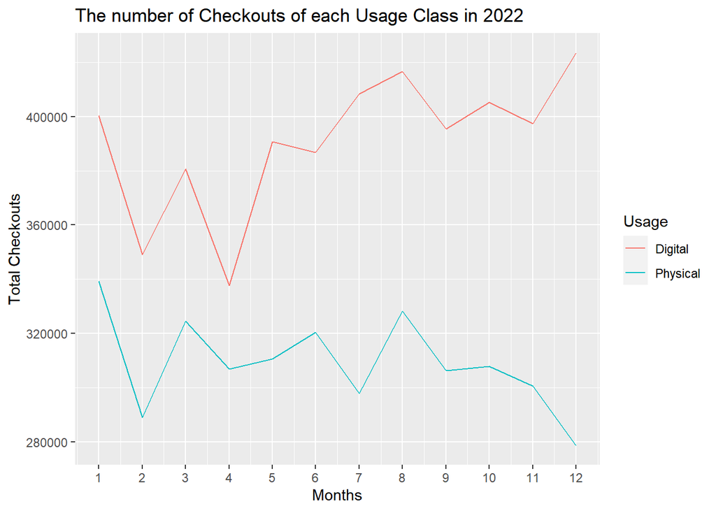

I included this chart to compare the number of checkouts between digital and physical usage class. I thought people will checkout digital more than physical type after the COVID-19, and my assumption was correct, as I could find out that digital had significantly more number of checkouts in every month than physical type.

### Second Trends Over Time Chart

Include a chart. Make sure to describe why you included the chart, and what patterns emerged

The second chart that you will create and include will show another trend over time of your variable/topic/interest. Think carefully about what you want to communicate to your user (you may have to find relevant trends in the dataset first!). Here are some requirements to help guide your design:

- Show more than one, but fewer than ~10 trends
  - For example, two books, or 5 different mediums
- You must have clear x and y axis labels
- The chart needs a clear title
- You need a legend for your different line colors and a clear - legend title In your .Rmd file, make sure to describe why you included the chart, and what patterns emerged

When we say “clear” or “human readable” titles and labels, that means that you should not just display the variable name.

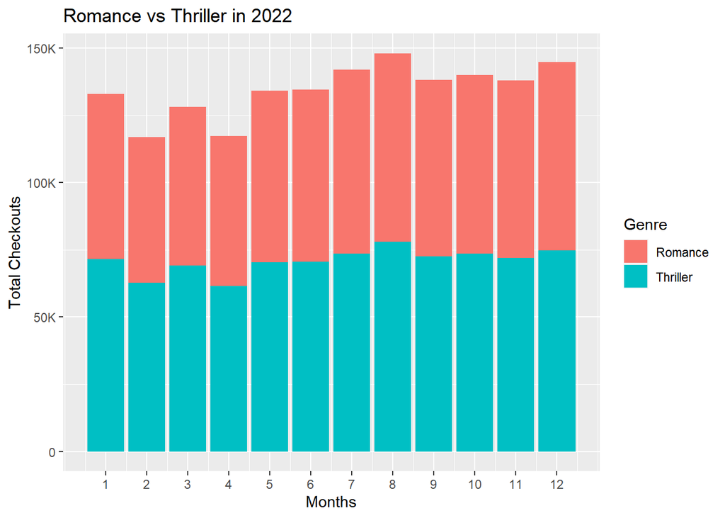

I included this chart to find out which genre, romance or thriller, is more popular. The reason I chose romance and thriller was those two are well known as the most popular type of book genre. Therefore, I made a stacked bar graph, and interestingly, it showed almost equal number of checkouts throughout the whole year.

### Your Choice

The last chart is up to you. It could be a line plot, scatter plot, histogram, bar plot, stacked bar plot, and more. Here are some requirements to help guide your design:

- You must have clear x and y axis labels
- The chart needs a clear title
- You need a legend for your different line colors and a clear legend title

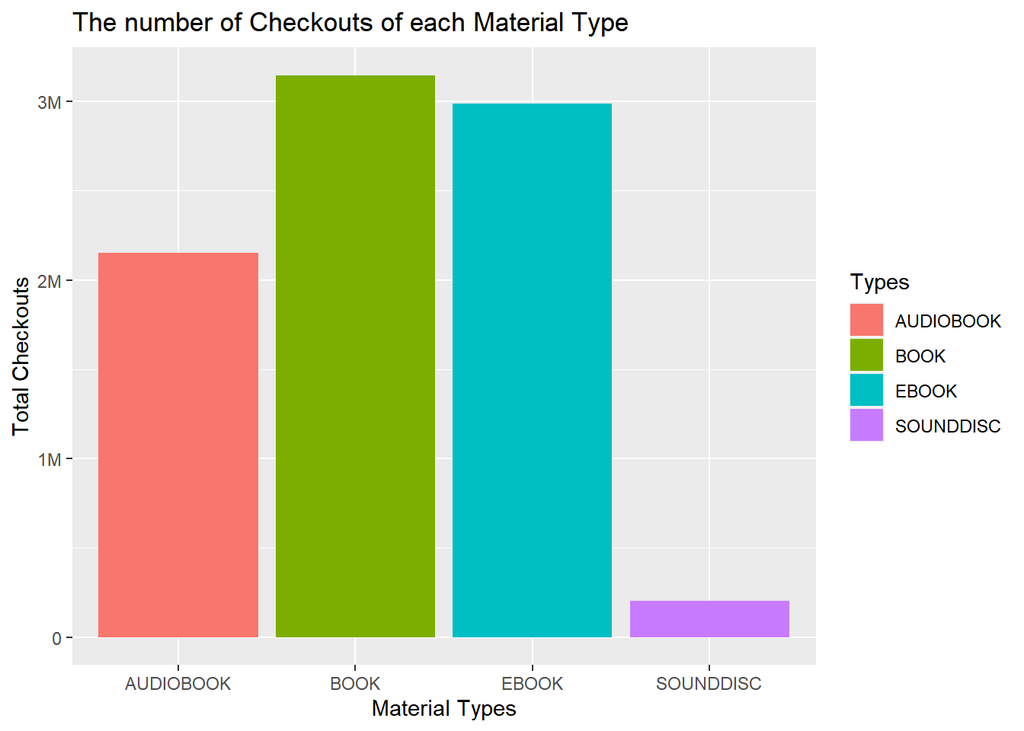

I made this chart because I wanted to compare the number of checkouts of each material type. I chose the four representative types of books- which is audio book, book, ebook and sounddisc, and book had the most number of checkouts among the four types.